# In-Class Session 9: Difference-in-Differences and Staggered Adoption

Econometrics I

This notebook reproduces the simulations behind Lectures 9a and 9b and leaves you five short problems. The slides use `did_sims.R` (in this folder) and `staggered_sims.R` (in `Fall/L10 - More Quasi Experiments/`), which run essentially the same simulations with more plotting. Everything is simulated, so you always know the right answer. A Python version of this notebook is `inclass_session9_py.qmd`.

# Part 1: The two-by-two (Lecture 9a)

## Reproduce: a SOX-404-style mandate

Firms with public float of at least $75M (“accelerated filers”) must comply from fiscal 2004; smaller firms are exempt. The outcome is log audit fees. The true effect is $+0.35$ in 2004, decaying to $+0.20$ by 2007. Larger firms are on a steeper audit-fee trend: `kappa` is the extra growth per year per standard deviation of size.

```r
years <- 2000:2007
tau_sox <- c(`2004` = 0.35, `2005` = 0.28, `2006` = 0.22, `2007` = 0.20)
sim_sox <- function(N = 2000, kappa = 0.06, sd_eps = 0.12) {
  lfloat <- rnorm(N, log(75), 1.2)
  size <- (lfloat - mean(lfloat)) / sd(lfloat)
  d <- CJ(firm = 1:N, year = years)
  d[, `:=`(size = size[firm], acc = as.integer(lfloat[firm] >= log(75)))]
  d[, alpha := 11 + 0.5 * size + rnorm(N, 0, 0.4)[firm]]
  gam <- cumsum(c(0, rnorm(length(years) - 1, 0.03, 0.02)))
  d[, post := as.integer(year >= 2004)]
  d[, tau := 0]
  d[acc == 1 & post == 1, tau := tau_sox[as.character(year)]]
  d[, y := alpha + gam[year - 1999] + kappa * size * (year - 2003) + tau + rnorm(.N, 0, sd_eps)]
  d[, D := acc * post]
  d[]
}
sox <- sim_sox()
```

The four routes to the $2\times2$ (fiscal 2003 vs. 2004):

```r
two <- sox[year %in% c(2003, 2004)]
cm <- two[, .(y = mean(y)), by = .(acc, year)]
dd_means <- with(cm, (y[acc == 1 & year == 2004] - y[acc == 1 & year == 2003]) -
                     (y[acc == 0 & year == 2004] - y[acc == 0 & year == 2003]))
w <- dcast(two, firm + acc + size ~ year, value.var = "y")
setnames(w, c("2003", "2004"), c("y03", "y04"))
w[, dy := y04 - y03]
fits <- list(
  fd   = feols(dy ~ acc, w, vcov = "hetero"),
  int  = feols(y ~ acc * post, two, vcov = ~firm),
  twfe = feols(y ~ D | firm + year, two, vcov = ~firm))
c(means = dd_means, fd = coef(fits$fd)[["acc"]], int = coef(fits$int)[["acc:post"]], twfe = coef(fits$twfe)[["D"]])
```

```
##    means       fd      int     twfe
## 0.448146 0.448146 0.448146 0.448146
```

They agree, and they all miss the truth of 0.35. Conditioning on size:

```r
fit_cond <- feols(dy ~ acc + size, w, vcov = "hetero")
coeftable(fit_cond)["acc", ]
```

```
##      Estimate    Std. Error       t value      Pr(>|t|)
##  3.548586e-01  1.258555e-02  2.819571e+01 1.603909e-147
```

And the event study, with and without size-specific year effects:

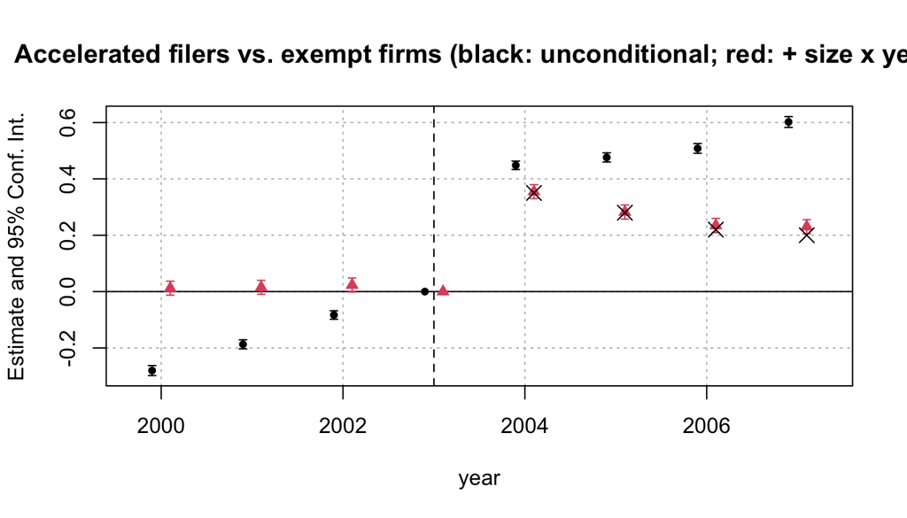

```r
fit_es   <- feols(y ~ i(year, acc, ref = 2003) | firm + year, sox, vcov = ~firm)
fit_es_c <- feols(y ~ i(year, acc, ref = 2003) + i(year, size, ref = 2003) | firm + year, sox, vcov = ~firm)
iplot(list(fit_es, fit_es_c), main = "Accelerated filers vs. exempt firms (black: unconditional; red: + size x year)")
points(2004:2007 + 0.1, tau_sox, pch = 4, cex = 1.5)   # truth
```

### Problem 1

Re-simulate with `kappa = 0` (no size trend). How far is the plain DiD from 0.35 now? Does adding size still change the estimate? What happens to its standard error relative to the plain DiD, and why? (Hint: how correlated are `acc` and `size`?)

```r
# your code here
```

### Problem 2

Replace the linear size control with size-decile fixed effects: `w[, dec := cut(size, quantile(size, 0:10/10), include.lowest = TRUE)]`, then `feols(dy ~ acc | dec, w)`. Which deciles contain both accelerated and exempt firms? What happens to the estimate and its standard error? Connect your answer to “conditioning needs overlap” and to regression discontinuity.

```r
# your code here
```

## Reproduce: placebo laws (Bertrand, Duflo and Mullainathan 2004)

A state-by-year panel with AR(1) errors. Half the states “pass a law” in a random year between 6 and 15. The law does nothing. How often does a 5% test reject?

```r
bdm_once <- function(S = 50, T = 20, rho = 0.8) {
  e <- matrix(0, S, T); e[, 1] <- rnorm(S, 0, 1 / sqrt(1 - rho^2))
  for (t in 2:T) e[, t] <- rho * e[, t - 1] + rnorm(S)
  d <- data.table(state = rep(1:S, T), t = rep(1:T, each = S), e = as.vector(e))
  start <- rep(Inf, S); tr <- sample(S, S / 2); start[tr] <- sample(6:15, length(tr), replace = TRUE)
  d[, y := rnorm(S)[state] + 0.1 * t + e]
  d[, D := as.integer(t >= start[state])]
  f <- feols(y ~ D | state + t, d)
  sapply(list(iid = "iid", hetero = "hetero", cluster = ~state),
         function(v) unname(pvalue(summary(f, vcov = v))["D"]) < 0.05)
}
rowMeans(replicate(200, bdm_once(S = 50, rho = 0.8)))
```

```
##     iid  hetero cluster
##   0.370   0.370   0.015
```

### Problem 3

Vary `rho` (0, 0.5, 0.9) and the number of states `S` (6, 10, 50; keep it even). Make a small table of rejection rates for clustered standard errors. Where does clustering stop working? Now give the law to only *one* state (edit `bdm_once`): what happens, and which slide tells you why?

```r
# your code here
```

# Part 2: Staggered adoption (Lecture 9b)

## Reproduce: an algorithm rolled out city by city

300 cities, 20 months, four launch waves (months 6, 9, 12, 15) and a never-treated group, 60 cities each. The effect ramps in over eight months and is larger for earlier waves.

```r
T_ <- 20; waves <- c(6, 9, 12, 15)
sim_rollout <- function(theta = c(`6` = 0.12, `9` = 0.09, `12` = 0.06, `15` = 0.04), ramp = 8, n_per = 60,
                        groups = c(waves, Inf)) {
  G <- rep(groups, each = n_per); N <- length(G)
  d <- CJ(id = 1:N, t = 1:T_)
  d[, g := G[id]]
  d[, alpha := rnorm(N, 0, 0.3)[id]]
  gam <- cumsum(rnorm(T_, 0.01, 0.02))
  d[, e := t - g]
  d[, D := as.integer(t >= g)]
  d[, tau := 0]
  d[D == 1, tau := theta[as.character(g)] * pmin(e + 1, ramp) / ramp]
  d[, y := alpha + gam[t] + tau + rnorm(.N, 0, 0.05)]
  d[, g_sa := ifelse(is.finite(g), g, 10000)]   # sunab's coding for never-treated
  d[]
}
d <- sim_rollout()
att_true <- d[D == 1, mean(tau)]
att_true
```

```
## [1] 0.06142857
```

Static two-way FE, and the weights it puts on each treated city-month (Frisch–Waugh–Lovell):

```r
fit_static <- feols(y ~ D | id + t, d, vcov = ~id)
d[, Dt := resid(feols(D ~ 1 | id + t, d))]
d[D == 1, w := Dt / sum(Dt)]
c(twfe = coef(fit_static)[["D"]], truth = att_true,
  share_negative_rows = d[D == 1, mean(w < 0)],
  estimand_from_weights = d[D == 1, sum(w * tau)])
```

```
##                  twfe                 truth   share_negative_rows
##            0.02597200            0.06142857            0.14285714
## estimand_from_weights
##            0.02691860
```

## Reproduce: three clean estimators

Sun and Abraham, via `sunab()`:

```r
fit_sa <- feols(y ~ sunab(g_sa, t) | id + t, d, vcov = ~id)
summary(fit_sa, agg = "ATT")
```

```
## OLS estimation, Dep. Var.: y
## Observations: 6,000
## Fixed-effects: id: 300,  t: 20
## Standard-errors: Clustered (id)
##     Estimate Std. Error t value  Pr(>|t|)
## ATT 0.060298   0.004823 12.5022 < 2.2e-16 ***
## ---
## Signif. codes:  0 '***' 0.001 '**' 0.01 '*' 0.05 '.' 0.1 ' ' 1
## RMSE: 0.047898     Adj. R2: 0.973242
##                  Within R2: 0.144642
```

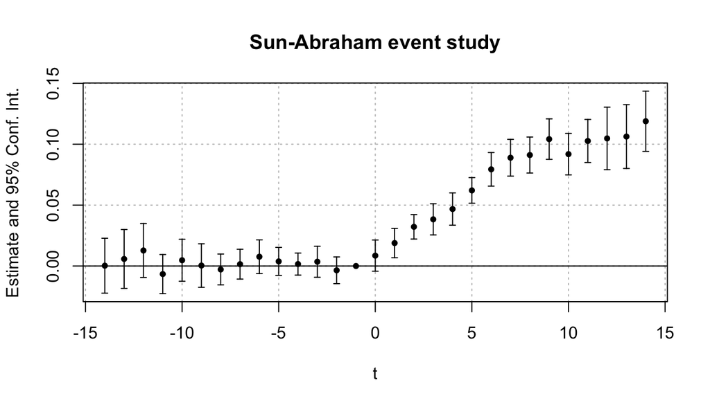

```r
iplot(fit_sa, main = "Sun-Abraham event study")
```

Callaway and Sant’Anna by hand: each $\text{ATT}(g,t)$ is a $2\times2$ against a clean comparison group, relative to month $g-1$; then average with cohort-size weights.

```r
cs_att <- function(d, control = "never") {
  wd <- dcast(d, id + g ~ t, value.var = "y"); Y <- as.matrix(wd[, -(1:2)]); G <- wd$g
  out <- list()
  for (g in waves) {
    ig <- which(G == g); b <- g - 1
    for (tt in g:T_) {
      ic <- if (control == "never") which(!is.finite(G)) else which(G > tt & G != g)
      if (length(ic) == 0) next
      out[[length(out) + 1]] <- data.table(g = g, t = tt, n = length(ig),
        att = mean(Y[ig, tt] - Y[ig, b]) - mean(Y[ic, tt] - Y[ic, b]))
    }
  }
  a <- rbindlist(out)
  a[, weighted.mean(att, n)]
}
c(cs_never = cs_att(d, "never"), cs_notyet = cs_att(d, "notyet"))
```

```
##   cs_never  cs_notyet
## 0.06029848 0.05899724
```

Imputation: fit city and month effects on untreated observations only, predict $Y(0)$ for the treated, average the gaps.

```r
f0 <- feols(y ~ 1 | id + t, d[D == 0])
tr <- d[D == 1]
tr[, tauhat := y - predict(f0, newdata = tr)]
c(imputation = tr[, mean(tauhat)], truth = att_true)
```

```
## imputation      truth
## 0.05811757 0.06142857
```

### Problem 4

Re-simulate with a constant effect: `sim_rollout(theta = c("6" = 0.06, "9" = 0.06, "12" = 0.06, "15" = 0.06), ramp = 1)`. Re-run static two-way FE and the three clean estimators. Which ones change, and why? Are any weights still negative? Why doesn’t that matter now?

```r
# your code here
```

### Problem 5

Drop the never-treated cities (`d[is.finite(g)]`). Callaway–Sant’Anna with not-yet-treated controls still works until the last wave launches. Run `cs_att()` with `control = "notyet"` and explain which $\text{ATT}(g,t)$ cells are missing and why. For Sun–Abraham, use the last wave as the reference cohort, `feols(y ~ sunab(g_sa, t, ref.c = 15) | id + t, d_no_never[t < 15])`. Why do you have to drop months 15 to 20?

```r
# your code here
```